# Study of census attributes in Bandundu

## Part 1: Building level

### Section 1: Overview of incomplete observations

Survey status for each observation

| Status | Count |
| --- | --- |
| Complete | 20714 |
| Incomplete | 217 |

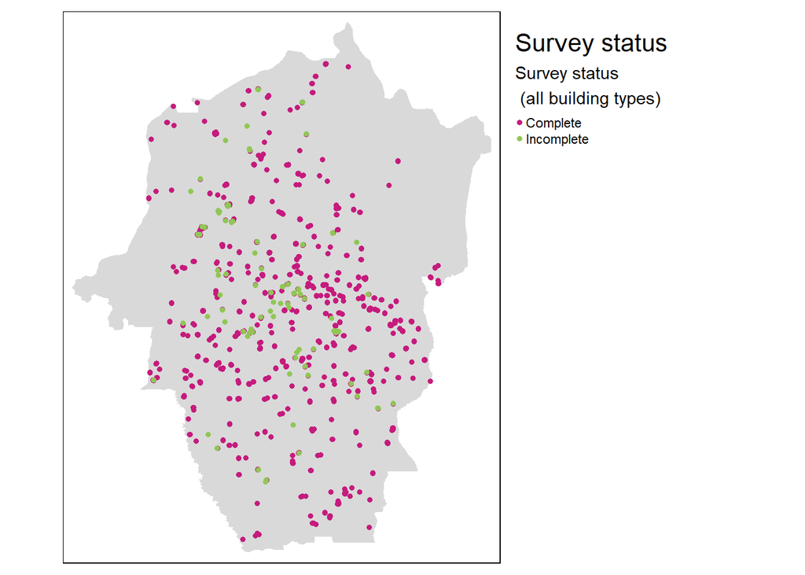

### Section 2: Sources of false incompleteness

#### 1. False report in `Survey_status`

*Situation*: Here we have on observation reported as `incomplete` but with household information filled and “nothing to report” on the `Comment` section.

*Solution*: We change it to `complete`. Concerns **1** observation.

| cluster_id | building_type | number_of_household | population | comments | status |
| --- | --- | --- | --- | --- | --- |
| drc_maindombe_0062 | Residential | 1 | 14 | Ras | Incomplete |

#### 2. Irrelevant buildings

*Situation*: as shown in the `comments`, some buildings reported as incomplete are actually not building that should contains people. Example: buildings reported abandonned, toilets, non occupied etc.

```r
pattern = c('on occup', 'Abandonn', 'vide', 'noccup',
            "existe plus",'En construction','Boutique','habit',
            'Douche', 'Wc', 'detrui', 'toilette', 'Non occup',
            'Cuisine', 'Abondonnee','Deplaement', 'occup','Inau')
census_res =census_res %>% filter(!(status=='Incomplete' & grepl(paste(pattern, collapse = "|"),comments)))
```

#### 3. Duplicate of completed observations

*Situation*: Sometimes when the surveyor came back to the household, he/she didn’t reopen the previous incomplete form such that for the same building we got two ids and two surveys, one completed and one incompleted (the first one in time). To flag it we based our analysis on the GPS coordinates (5 digits accuracy for the longitude, 6 for the lattitude), two buildings having the same coordinates were considered as the same.

*Solution*: we remove these incomplete observations. Concerns **9** observations

> Caveat: I’m not sure that this procedure is correct since in the full data table, there are 272 entries that have non-unique GPS coordinates.

Survey status for each observation after modifications

[output not shown]

### Section 3: Caracteristics of incomplete survey

#### Brief description

For the remaining incomplete observations: we have information about: - the number of floors (all at 1 except one at 174 considered as irrelevant outlier) - the number of household in the building (all 1 except one at 2)

but no more. We have no other information for imputation.

### Section 4: Additional buildings surveyed

when we look at the `household` dataset, we notice that 30 buildings have been surveyed without being in the `building` dataset. They were reported as `non-residential` (even though they are absent from the `building` dataset corresponding to the non-residential ones).

What does it mean: we have more observations and we need to merge them with the others. It’s possible because they have a building_id and a GPS coordinates. But we lacked the `comments`, the `interviewer_name`and the `number_of_floors` that are the information reported only at the building level.

```
## [1] "Number of additional observations: 30"
```

```
## [1] "Final number of buildings surveyed: 20849"
```

## Part 2: Household level

#### Flag incompleteness

We know the number of households that are supposed to live in the building from the `building` dataset and we know the number of households that have actually have been interviewed from the `household` dataset. We can thus flag buildings where not every household has been interviewed, information of prime importation for imputation purposes.

| cluster_id | building_type | number_of_floors | calculated_no_household | comments | population | hh_obs | nb_hh_incomp |
| --- | --- | --- | --- | --- | --- | --- | --- |
| drc_maindombe_0005 | Residential | 1 | 3 | Ras | 9 | 2 | 1 |
| drc_kwilu_0075 | Residential | 1 | 3 | Erreur de ddoublement | 4 | 1 | 2 |
| drc_maindombe_0062 | Residential | 1 | 2 | Ras | 14 | 1 | 1 |
| drc_maindombe_0079 | Residential | 1 | 2 | Ras | 7 | 1 | 1 |
| drc_maindombe_0079 | Residential | 1 | 2 | Ras | 5 | 1 | 1 |
| drc_kwilu_0075 | Residential | 1 | 3 | Ras | 4 | 1 | 2 |
| drc_maindombe_0050 | Residential | 1 | 2 | /Refus ( 2) | 1 | 1 | 1 |
| drc_maindombe_0059 | Residential | 1 | 35 | Ras | 1 | 1 | 34 |
| drc_maindombe_0026 | Residential | 1 | 2 | Absence de personne mousse donner les informations | 2 | 1 | 1 |
| drc_kwilu_0045 | Residential | 1 | 2 | Ras | 1 | 1 | 1 |
| drc_maindombe_0028 | Residential | 1 | 2 | Mnage et cuisine | 1 | 1 | 1 |
| drc_maindombe_0059 | Mixed | 1 | 2 | Deuxieme piece est une pallote | 10 | 1 | 1 |
| drc_kwilu_0075 | Residential | 1 | 2 | Erreur de ddoublement | 3 | 1 | 1 |

```
## [1] "Potential missing household observation: 13"
```